# Clone detection stuff

# Setup

## Installing required software

The following must be installed:

- js-tokenizer

> TODO Fill in what to install, where to install it, etc.

## Running the clone detection

> TODO tokenizer is a bit of mess now, must fix and write this section

## Validating the tokenizer results

(note this takes a looong time)

## This notebook

This notebook and its scripts provide all functionality required to run the analysis of Javascript tokenization and clone detection. It assumes that you have already installed all the required software and executed the tokenizer and clone detector, as described in previous chapters.

When done, please read this section carefully as it guides you through the necessary setup you must perform in order to be able to run the code below. All of the configucation variables can either be specified here in the notebook and saved before the execution, or you may create local file named `local.r` and set the variables in it. At the end of the setup section, the script will automatically check for its existence and source it if found, overriding anything that is set in the notebook itself.

In order to run code in this notebook, we must load the required R scripts for database access and data manipulation.

```r
source("clone_detection.r")
```

### Configuration

We must then set up the database connection, please make sure that these values correspond to what you need:

```r
MYSQL_HOST = "localhost"
# this user must be powerful enough to create databases, or the database must already exist
MYSQL_USER = "sourcerer"
MYSQL_PASSWORD = "js"
```

For the data loading and preprocessing, you may specify the override flag. During this phase the script checks that the data in the database correspond to the data on the disk by comparing the timestamps. If this situation is detected and `OVERRIDE` is set to `F` an error is printed, but the data in the database will not be touched. If it is `T`, then no error is printed, but the data is reloaded. And finally, if the flag is set to `"force"`, the data will be reloaded regardless of the timestamp. Setting the flag here has global validity, but you can also pass it to the loading and preprocessing functions to do a per-function update.

We also set the `DT_LIMIT` which the script uses to limit the sizes of the data tables when presented

```r
OVERWRITE = T
DT_LIMIT = 20
```

Next we have to prepare the database and tables and load the data produced by the tokenizer and sourcerer. For this, we must specify the root folder where the tokenizer output files are stored, and where the sourcerer CC’s output for this particular set is stored. We must also name the database which will be created for the data. By default, the name of the output dir is used, but you may change this.

> By default, we assume you have copied sourcerer CC’s output into the sourcerer directory of the tokenizer output, but you may change this if you want.

```r
TOKENIZER_OUTPUT_DIR = "tokenizer/output/files"
SOURCERER_OUTPUT_DIR = paste(TOKENIZER_OUTPUT_DIR, "sourcerer", sep = "/")
MYSQL_DB_NAME = tail(strsplit(TOKENIZER_OUTPUT_DIR, "/")[[1]], n = 1)
```

Finally, let’s check if we have local configuration and use that one instead of the one supplied with the notebook for easier management:

```r
if (file.exists("local.r")) {
    println("Using local cofiguration instead:")
    source("local.r")
    println("  MYSQL_HOST:           ", MYSQL_HOST)
    println("  MYSQL_DB_NAME:        ", MYSQL_DB_NAME)
    println("  MYSQL_USER:           ", MYSQL_USER)
    #println("  MYSQL_PASSWORD:       ", MYSQL_PASSWORD) #-- we do not want the password to be in the document
    println("  TOKENIZER_OUTPUT_DIR: ", TOKENIZER_OUTPUT_DIR)
    println("  SOURCERER_OUTPUT_DIR: ", SOURCERER_OUTPUT_DIR)
    println("  OVERWRITE:            ", OVERWRITE)
    println("  DT_LIMIT:             ", DT_LIMIT)
}
```

```
## Using local cofiguration instead:
##   MYSQL_HOST:           localhost
##   MYSQL_DB_NAME:        aws_withminjs_v6
##   MYSQL_USER:           sourcerer
##   TOKENIZER_OUTPUT_DIR: /home/peta/sourcerer/reporting/aws_withminjs_v6
##   SOURCERER_OUTPUT_DIR: /home/peta/sourcerer/reporting/aws_withminjs_v6/sourcerer
##   OVERWRITE:            TRUE
##   DT_LIMIT:             20
```

```r
println("Using database ", MYSQL_DB_NAME)
```

```
## Using database aws_withminjs_v6
```

### Running this notebook

There are two options how you can run this notebook. You can use *RStudio*, which is better for interactivity and playing with the data, or you can use R’s command line tools to generate the HTML w/o the need of RStudio and gui. In both cases the renderer runs all R code in this document and interleaves its results with the text.

#### Running from RStudio

Download the latest RStudio as specified in [R notebooks](http://rmarkdown.rstudio.com/r_notebooks.html) in RStudio, so make sure to follow their advice. Once installed, you may open the `Rmd` file and then either hit `CTRL-ALT-R` which makes RStudio rerun all the code segments in the IDE itself. Alternatively you may execute current code segment by pressing `CTRL+Enter`. If you want to produce the clean html document instead, click on the *Knit HTML* (`CTRL+SHIFT+K`) command.

#### Running from console

You can also create the HTML document directly from R, using the `rmarkdown::render` function. Before doing so, the *pandoc* must be [setup properly](https://github.com/rstudio/rmarkdown/blob/master/PANDOC.md).

> TODO I have not actually tested it as on my machine

## Preprocessing

Let’s connect to the database server, create the database, load the data from tokenizer and sourcerer and preprocess it. These steps are only pefrormed if they are deemed necessary. The script uses timestamp data for the respective databases and reloads, or recreates the data only if necessary.

```r
# connect to the database and create the table if it does not exist
sql.connect(MYSQL_USER, MYSQL_PASSWORD, MYSQL_DB_NAME)

# load tokenizer data into the database
sql.loadTokenizerData(TOKENIZER_OUTPUT_DIR)
```

```
## bookkeeping_proj - project to path mapping
## tokenizer_clones - clone pairs as reported by the tokenizer
## files_stats - file statistics in sourcererCC's format
## files_full_stats - file statistics in our format (extra info our tokenizer generates)
## tokens - tokens and their frequencies as reported by the tokenizer for all files
## timestamp - bookkeeping information about the data used
## Database already created on 2016-11-02 20:13:07
## Skipping loading table bookkeeping_proj - already loaded, timestamp: 2016-09-29 17:49:02
##   69870 entries [7880704 bytes]
## Skipping loading table tokenizer_clones - already loaded, timestamp: 2016-09-29 17:50:14
##   18828404 entries [1210023936 bytes]
## Skipping loading table files_stats - already loaded, timestamp: 2016-09-29 17:50:13
##   1503025 entries [553582592 bytes]
## Skipping loading table files_full_stats - already loaded, timestamp: 2016-09-29 17:50:14
##   19105122 entries [5716836352 bytes]
## Skipping loading table tokens - already loaded, timestamp: 2016-09-29 17:51:38
##   56094744 entries [7734247424 bytes]
```

```r
# create preprocessed tables for the tokenizer
sql.createTokenizerPreprocessedTables()
```

```
## tokenizer_clone_groups - clone groups for files reported by the tokenizer as identical
## tokenizer_clone_info - relation between cloned files and their clone groups as reported by the tokenizer (identical files)
## non_empty_files - non empty files as reported by the tokenizer
## project_stats - cummulative information about projects
## tokenizer_project_stats_original - cummulative information about projects taken only from original files (as reported by the tokenizer)
## tokens_size - sizes of tokens
```

```r
# calculate clone groups as reported by the tokenizer
calculateCloneGroups("tokenizer_clones", "tokenizer_clone_groups", "tokenizer_clone_info")
```

```
## Skipping clone groups preprocessing into tokenizer_clones - already created, timestamp: 2016-09-29 17:50:14
##   14829897 entries [1156562944 bytes]
##   793314 clone groups [26787840 bytes]
```

```r
# calculate non-empty files from the full statistics
calculateNonEmptyFiles()
```

```
## Skipping preprocessing non-empty files - already done, timestamp: 2016-09-29 17:50:14
##   18506836 entries [441319424 bytes]
```

```r
# calculate project statistics
calculateProjectStats()
```

```
## Skipping calculating project statistics - already done, timestamp: 2016-09-29 17:50:14
##   72192 entries [6832128 bytes]
## Skipping calculating project statistics from original files - already done, timestamp: 2016-09-29 17:50:14
##   65653 entries [19415040 bytes]
```

```r
# calculate token sizes
# TODO the tokenizer is perhaps better to calculate this since we are calculating the length of escaped tokens here
calculateTokenSizes()
```

```
## Skipping calculating token sizes - already done, timestamp: 2016-09-29 17:51:38
##   38952383 entries [1094713344 bytes]
```

```r
println("\nTotal database size ", sum(sql.query("SHOW TABLE STATUS")$Data_length) / 1024 / 1024, " [Mb]")
```

```
##
## Total database size 17135.828125 [Mb]
```

# Results

We are now going to look at various simple statistics we can obtain from the tokenizer output. Where applicable, both summaries and histograms of the specified variables are shown. Note that most of the histogram scales are logarithmic.

## Tokenizer Output Stats

```r
files = list()
files$total = sql.table.status("files_full_stats")$length
files$unique = sql.table.status("files_stats")$length
# empty files are not part of the sourcererCC's input and must therefore be excluded
files$empty = sql.query("SELECT COUNT(*) FROM files_full_stats WHERE totalTokens=0")[[1]]
# files that are reported as not fully understood by the tokenizer
files$error = sql.query("SELECT COUNT(*) FROM files_full_stats WHERE errors>0")[[1]]

println("Total files:    ", files$total)
```

```
## Total files:    19105122
```

```r
println("Unique files:   ", files$unique, "  ", files$unique / files$total, "%")
```

```
## Unique files:   1503025  0.0786713112850051%
```

```r
println("Empty files:    ", files$empty, "  ",files$empty / files$total, "%")
```

```
## Empty files:    72170  0.00377752102289637%
```

```r
println("Error files:    ", files$error, "  ", files$error / files$total, "%")
```

```
## Error files:    51339  0.00268718514333486%
```

> If the ratio of error files is high, then the tokenizer cannot be trusted to produce meaningful results, but small number of error files is totally ok - some of the javascript files are test cases that should error.

### Basic information about files

```r
# file size in bytes
x <- sql.query("SELECT bytes FROM files_full_stats")$bytes
summary(x)
```

```
##     Min.  1st Qu.   Median     Mean  3rd Qu.     Max.
##        0      938     2388    20370     7324 96320000
```

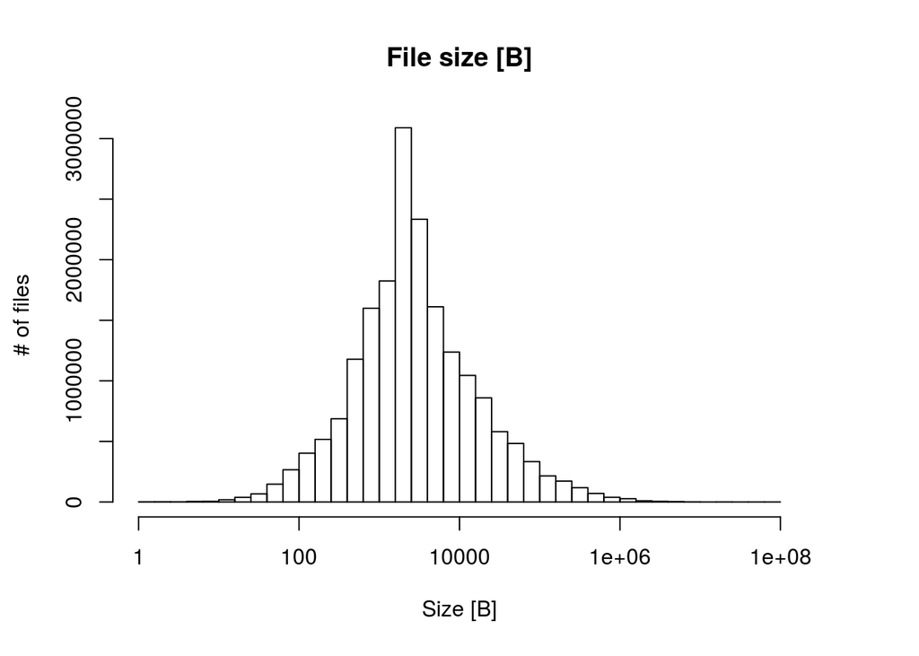

```r
logHist(x, main = "File size [B]", xlab = "Size [B]", ylab = "# of files")
```

```r
# file size in lines of code (including empty and comments)
x <- sql.query("SELECT loc FROM files_full_stats")$loc
summary(x)
```

```
##      Min.   1st Qu.    Median      Mean   3rd Qu.      Max.
##       1.0      10.0      42.0     423.1     129.0 2794000.0
```

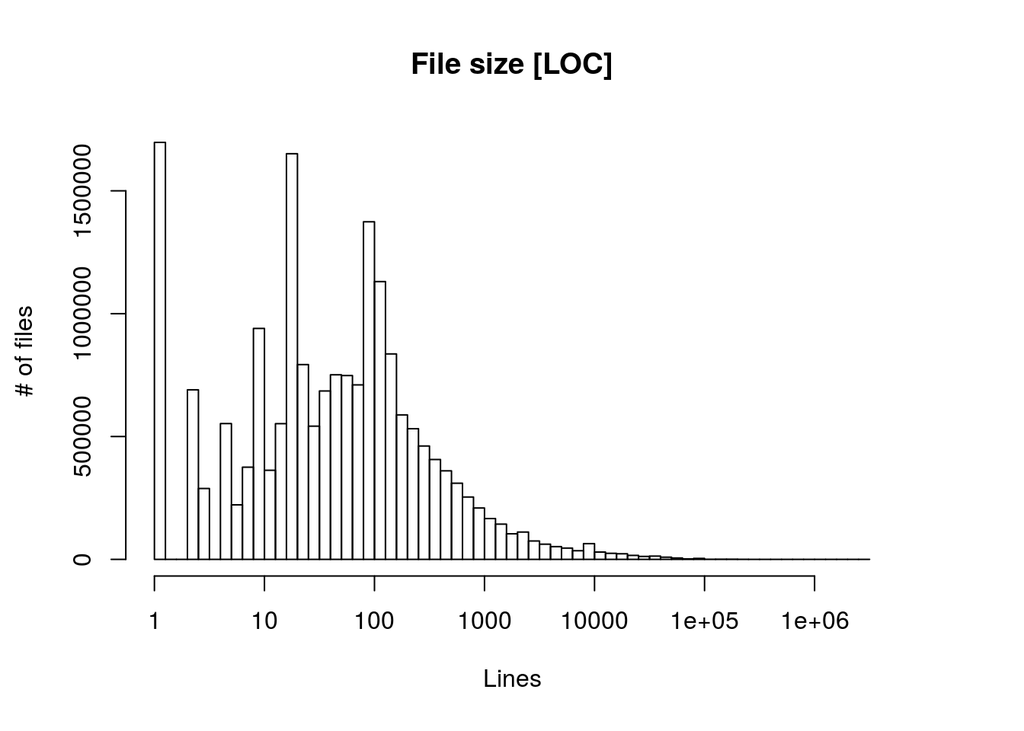

```r
logHist(x, main = "File size [LOC]", xlab = "Lines", ylab = "# of files")
```

```r
# # of total tokens in files
x <- sql.query("SELECT totalTokens FROM files_full_stats")$totalTokens
summary(x)
```

```
##     Min.  1st Qu.   Median     Mean  3rd Qu.     Max.
##        0       60      177     1779      569 12000000
```

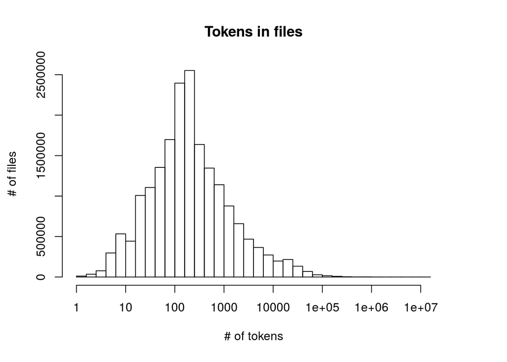

```r
logHist(x, main = "Tokens in files", xlab = "# of tokens", ylab = "# of files")
```

```r
# # of unique tokens in files (excluding repetitions)
# TODO old tokenizer did not report this correctly
#x <- sql.query("SELECT uniqueTokens FROM files_full_stats")$uniqueTokens
#summary(x)
#logHist(x, main = "Unique Tokens per File", xlab = "# of tokens", ylab = "# of files")
```

> We believe the peak at 1 LOC is due to min.js files which are minified version of javascript with no extra whitespace, and therefore no line breaks so the entire file is a single line.

### Composition of files

```r
# % of comments in the files
x <- sql.query("SELECT (commentBytes/bytes) AS result FROM non_empty_files AS ne, files_full_stats AS fs WHERE ne.id = fs.id")$result
summary(x)
```

```
##    Min. 1st Qu.  Median    Mean 3rd Qu.    Max.
##  0.0000  0.0000  0.0628  0.1788  0.2977  1.0000
```

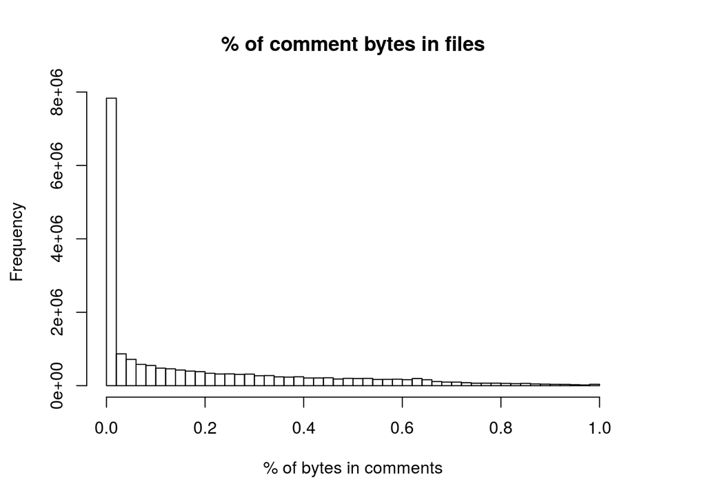

```r
normalHist(x, main = "% of comment bytes in files", xlab = "% of bytes in comments")
```

```r
# % of whitespace in the files
x <- sql.query("SELECT (whitespaceBytes/bytes) AS result FROM non_empty_files AS ne, files_full_stats AS fs WHERE ne.id = fs.id")$result
summary(x)
```

```
##    Min. 1st Qu.  Median    Mean 3rd Qu.    Max.
##  0.0000  0.0116  0.1221  0.1363  0.2209  1.0000
```

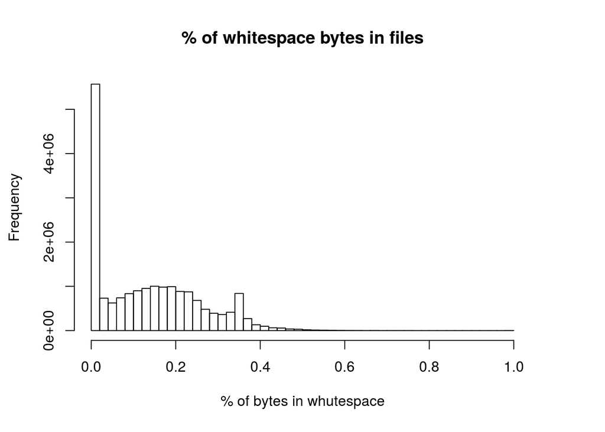

```r
normalHist(x, main = "% of whitespace bytes in files", xlab = "% of bytes in whutespace")
```

```r
# % of separators in the files
x <- sql.query("SELECT (separatorBytes/bytes) AS result FROM non_empty_files AS ne, files_full_stats AS fs WHERE ne.id = fs.id")$result
summary(x)
```

```
##    Min. 1st Qu.  Median    Mean 3rd Qu.    Max.
##  0.0000  0.0688  0.1037  0.1165  0.1460  1.0000
```

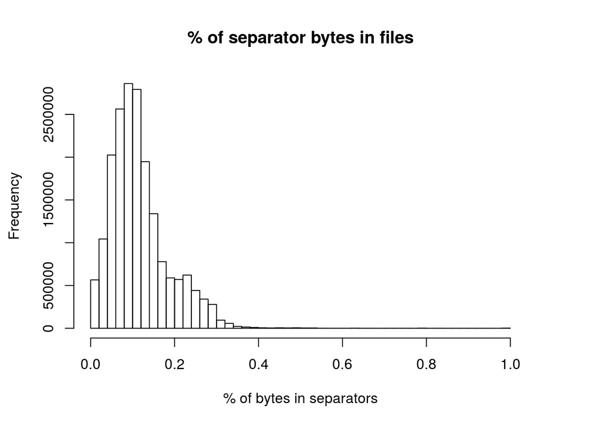

```r
normalHist(x, main = "% of separator bytes in files", xlab = "% of bytes in separators")
```

```r
# % of tokens in the files
x <- sql.query("SELECT (tokenBytes/bytes) AS result FROM non_empty_files AS ne, files_full_stats AS fs WHERE ne.id = fs.id")$result
summary(x)
```

```
##    Min. 1st Qu.  Median    Mean 3rd Qu.    Max.
##  0.0000  0.4261  0.5801  0.5684  0.7251  1.5000
```

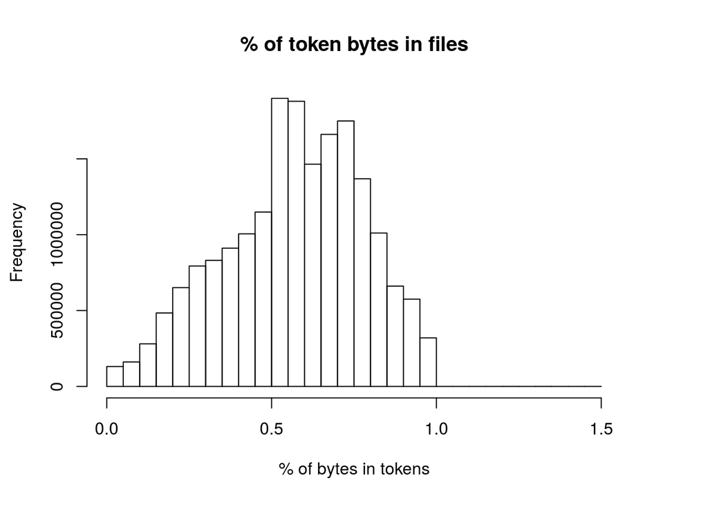

```r
normalHist(x, main = "% of token bytes in files", xlab = "% of bytes in tokens")
```

> Again the large number of files with 0 whitespace is due to minified javascript files. We will confirm this later by rerunning the tokenizer and excluding these.

### Basic Information about projects

```
x <- sql.query("SELECT ", field, " AS field FROM ", table)
x$field
```

```r
x <- sql.query("SELECT files FROM project_stats")$files
summary(x)
```

```
##     Min.  1st Qu.   Median     Mean  3rd Qu.     Max.
##      1.0      4.0     15.0    262.8     73.0 409000.0
```

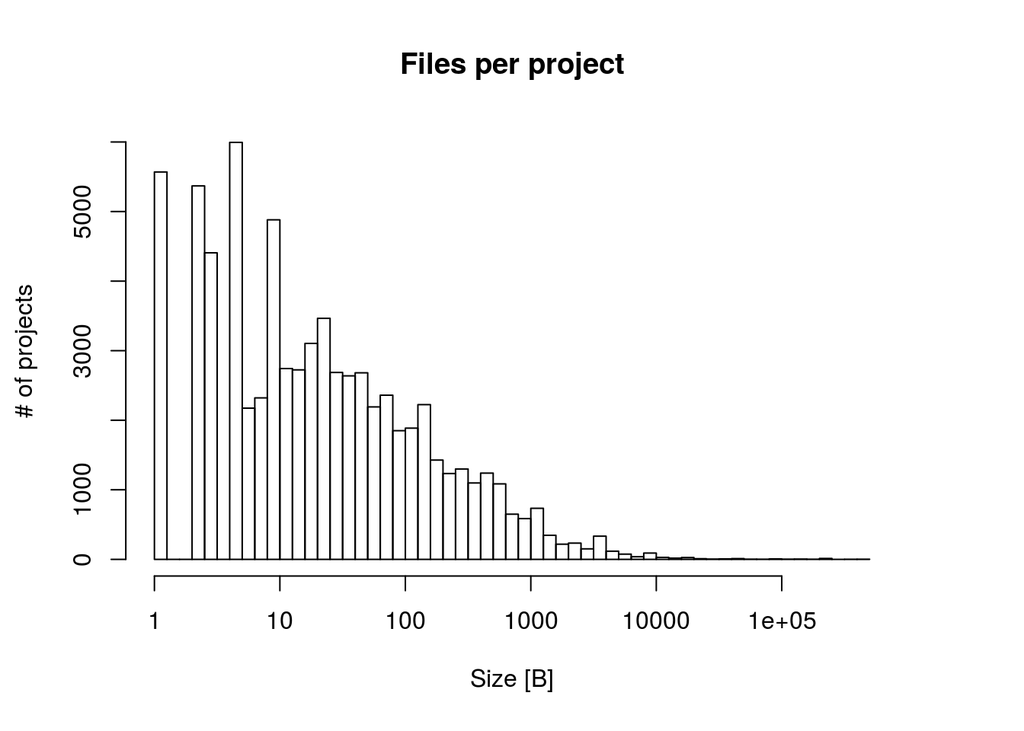

```r
logHist(x, main = "Files per project" , xlab = "Size [B]", ylab = "# of projects")
```

```r
x <- sql.query("SELECT bytes FROM project_stats")$bytes
summary(x)
```

```
##      Min.   1st Qu.    Median      Mean   3rd Qu.      Max.
## 0.000e+00 3.776e+04 2.699e+05 5.353e+06 1.280e+06 9.812e+09
```

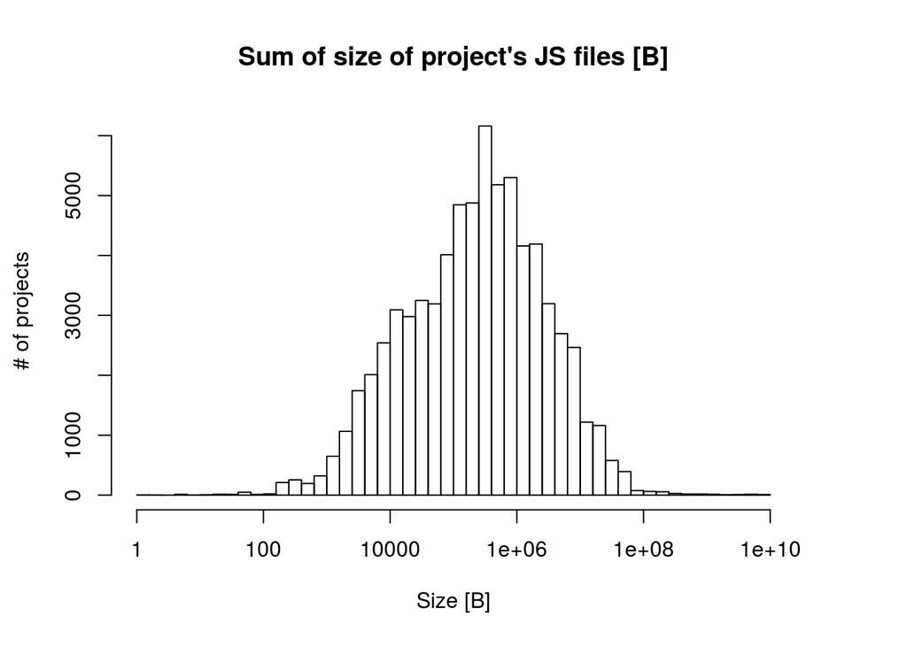

```r
logHist(x, main = "Sum of size of project's JS files [B]", xlab = "Size [B]", ylab = "# of projects")
```

```r
x <- sql.query("SELECT loc FROM project_stats")$loc
summary(x)
```

```
##      Min.   1st Qu.    Median      Mean   3rd Qu.      Max.
##         1       811      5530    111200     29600 197400000
```

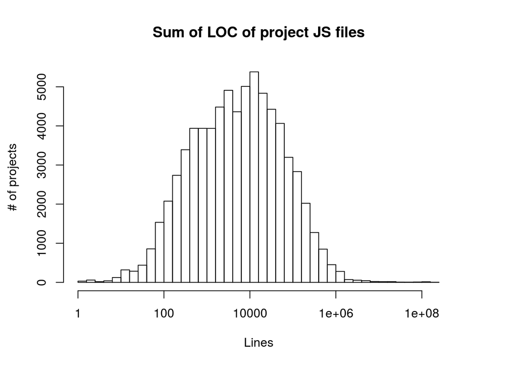

```r
logHist(x, main = "Sum of LOC of project JS files", xlab = "Lines", ylab = "# of projects")
```

Some of the projects are surprisingly large. Let us examine the largest projects out there:

```r
x <- sql.query("SELECT path, bytes, files FROM project_stats, bookkeeping_proj WHERE id=projectId ORDER BY bytes DESC LIMIT ", DT_LIMIT)
x$path <- sapply(x$path, unescape)
x
```

| path | bytes | files |
| --- | --- | --- |
| /mnt/data1/data70k/GaryChamberlain/cdnjs_GaryChamberlain/cdnjs/latest | 9811566606 | 408989 |
| /mnt/data2/data70k2/t/tmorin/cdnjs/latest | 8976185465 | 399220 |
| /mnt/data2/data70k2/p/pcarrier/cdnjs/latest | 8771491375 | 393787 |
| /mnt/data2/data70k2/j/jtlan/cdnjs/latest | 6839943706 | 234460 |
| /mnt/data1/data70k/amendezr2d2/cdnjs_amendezr2d2/cdnjs/latest | 6756799840 | 233611 |
| /mnt/data1/data70k/coupang/cdnjs_coupang/cdnjs/latest | 6694753622 | 232447 |
| /mnt/data2/data70k2/j/jpburn/cdnjs/latest | 6593692794 | 231704 |
| /mnt/data1/data70k/AMoo-Miki/cdnjs_AMoo-Miki/cdnjs/latest | 6422843978 | 227134 |
| /mnt/data2/data70k2/k/kamasteve/cdnjs/latest | 6386083621 | 226355 |
| /mnt/data1/data70k/DanielBGomez/cdnjs_DanielBGomez/cdnjs/latest | 5876460826 | 214912 |
| /mnt/data2/data70k2/k/kuldeeppanchal164/cdnjs/latest | 5784956908 | 213536 |
| /mnt/data2/data70k2/m/merkjs/cdnjs/latest | 5721597438 | 212923 |
| /mnt/data2/data70k2/l/luisorozoli/cdnjs/latest | 5614325492 | 211174 |
| /mnt/data1/data70k/TimFerrell/cdnjs_TimFerrell/cdnjs/latest | 5547370260 | 208632 |
| /mnt/data1/data70k/Krotixnetwork/cdnjs_Krotixnetwork/cdnjs/latest | 5499988583 | 207503 |
| /mnt/data2/data70k2/v/vostokiya/cdnjs/latest | 5356787844 | 206328 |
| /mnt/data2/data70k2/k/kickbox/fabricjs.com/latest | 5078166607 | 17224 |
| /mnt/data2/data70k2/m/mkozhukh/cdnjs/latest | 4745465187 | 163187 |
| /mnt/data2/data70k2/v/vedranmiletic/cdnjs/latest | 4703257126 | 161220 |
| /mnt/data2/data70k2/s/simondoty/cdnjs/latest | 4598443888 | 154656 |

> TODO the tokenizer should also output github url for the project so that we can easily access them rather than clumsy local path

### Information about tokens

```r
# token's size
x <- sql.query("SELECT textSize FROM tokens_size")$textSize
summary(x)
```

```
##     Min.  1st Qu.   Median     Mean  3rd Qu.     Max.
##        0       11       18      107       34 22640000
```

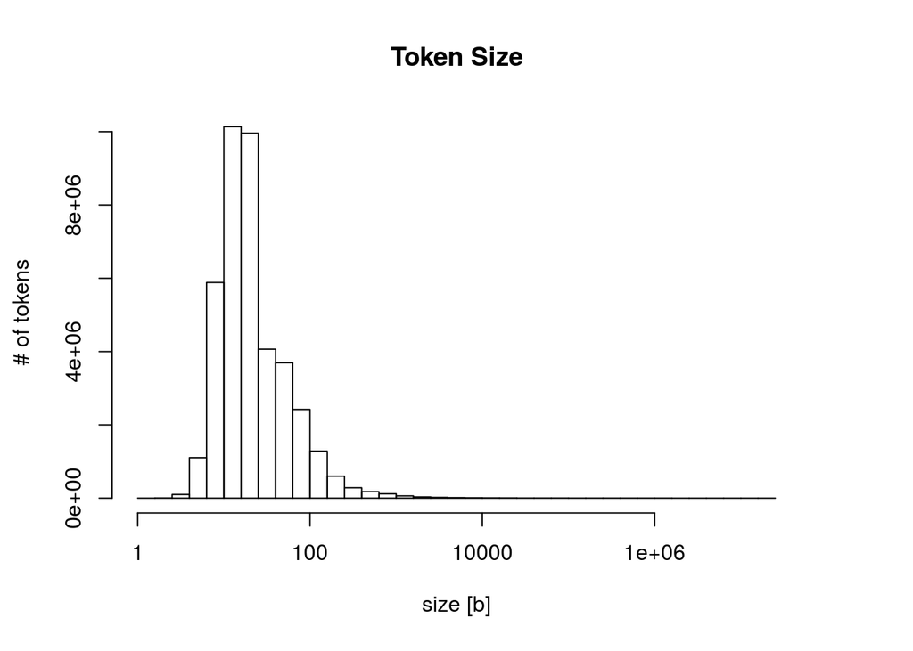

```r
# histogram over the entire range
logHist(x, main = "Token Size", xlab = "size [b]", ylab = "# of tokens")
```

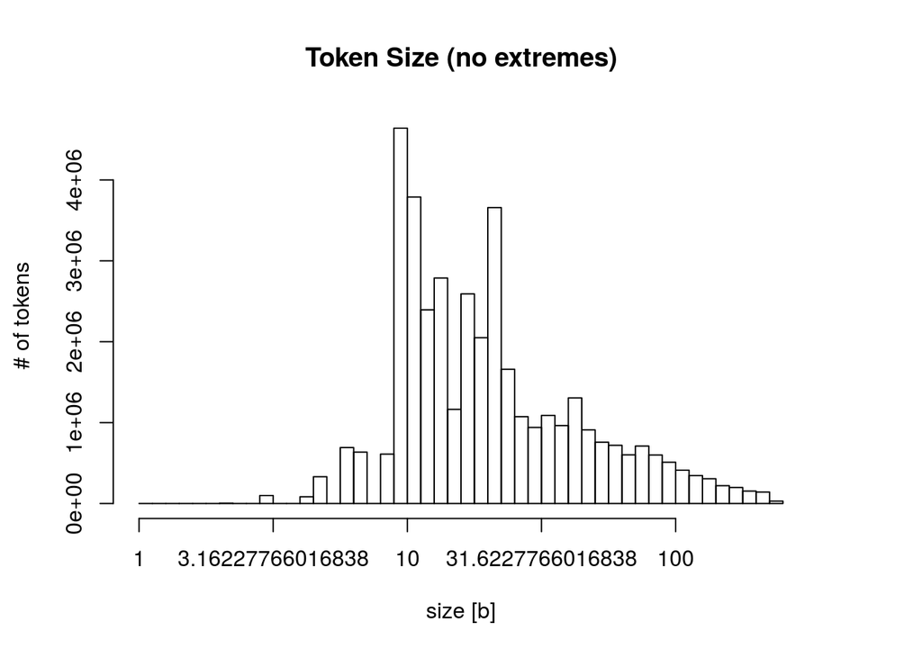

```r
# histogram of token sizes w/o extremes
p <- quantile(x, .98)
logHist(x[ x < p ], main = "Token Size (no extremes)", xlab = "size [b]", ylab = "# of tokens")
```

Let’s now examine the longest tokens to see how they look like. The table shows the beginnings of the longest tokens, their size and # of occurences in the corpus.

```r
x <- sql.query("SELECT LEFT(text, 200) as text, textSize, count FROM tokens AS tk, tokens_size AS ts WHERE tk.id = ts.id ORDER BY textSize DESC LIMIT ", DT_LIMIT)
x$text <- sapply(x$text, unescape50)
x
```

[output not shown]

Let’s also look at token frequencies:

```r
x <- sql.query("SELECT count FROM tokens")$count
summary(x)
```

```
##     Min.  1st Qu.   Median     Mean  3rd Qu.     Max.
##        1        1        2      111        8 15090000
```

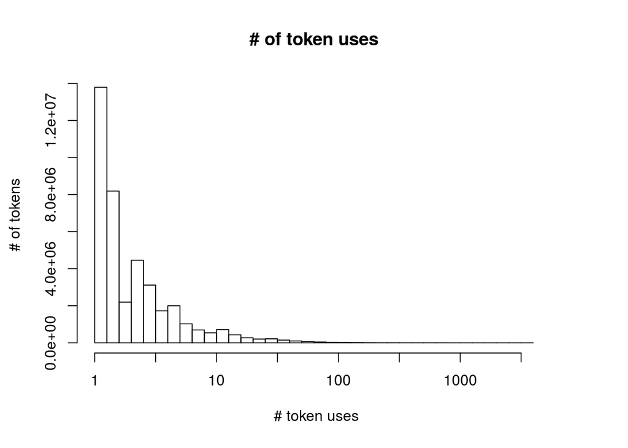

```r
logHist(x, main = "# of token uses", xlab = " # token uses", ylab = "# of tokens", base = 100)
```

> I have left out the detailed exploration of this graph because it was no longer adequate. Also there were no real findings from it at this point.

Let’s look at the most frequently used tokens:

```r
x <- sql.query("SELECT LEFT(text, 200) as text, count FROM tokens ORDER BY count DESC LIMIT ", DT_LIMIT)
x$text <- sapply(x$text, unescape50)
x
```

| text | count |
| --- | --- |
| function | 15085409 |
| var | 13797052 |
| return | 12011797 |
| 0 | 11449731 |
| if | 10910997 |
| 1 | 10407584 |
| this | 7568504 |
| length | 7365793 |
| 2 | 6989168 |
| else | 6579660 |
| i | 6562795 |
| null | 6399919 |
| new | 6272746 |
| true | 6042672 |
| module | 5718858 |
| “” | 5679205 |
| for | 5570621 |
| value | 5445814 |
| 3 | 5397133 |
| e | 5391790 |

## Data analysis of clones

All files that are reported to be clone of each other belong to a *clone group*.

```r
# displays the clone info as obtained from given clone group tables
displayCloneGroupsInfo <- function(clone.groups, clone.info, input.files) {
    nf <- sql.table.status(input.files)$length
    nc <- sql.table.status(clone.info)$length
    ncg <- sql.table.status(clone.groups)$length
    println("Input files:              ", nf)
    println("Files which have clones:  ", nc)
    println("Clone groups:             ", ncg)
    println("Original files:           ", nf - nc + ncg, "  ", (nf - nc + ncg)/ nf, "[%]")
}

displayFilesPerCloneGroup <- function(clone.groups) {
    # histogram of number of files in a clone group
    x <- sql.query(" SELECT files FROM ", clone.groups)$files
    print(summary(x))
    logHist(x, main = "# of files in a clone group ", xlab = " # of files in group", ylab = "# of clone groups", base = 100)
}

displayProjectsPerCloneGroup <- function(clone.groups) {
    # number of projects per clone group
    x <- sql.query(" SELECT projects FROM ", clone.groups)$projects
    print(summary(x))
    logHist(x, main = "# of projects in a clone group ", xlab = " # of projects in group", ylab = "# of clone groups", base = 100)
}
```

A simple function that displays most cloned files, counted either by number of copies, or by number of projects that contain a copy. Please note that the links to the files provided here are simply links to the clone group identifier, which is the first file reported as clone by the input data, it does not mean that it is the original.

```r
mostClonedFiles <- function(clone.groups, countBy) {
    # displaying clickable url in the final document
    x <- sql.query("SELECT url, files, projects FROM ",clone.groups, " JOIN files_stats WHERE groupId=id ORDER BY ",countBy," DESC LIMIT ", DT_LIMIT)
    x$url <- sapply(x$url, unescape)
    x
}
```

```r
originalContent <- function(table, content) {
    x <- sql.query("SELECT (orig.", content ," / all_.", content ,") AS pct FROM ", table, " AS orig, project_stats AS all_ WHERE all_.projectId=orig.projectId AND all_.", content," > 0")$pct
    print(summary(x))
    normalHist(x, main = paste("% of original", content, "in projects"), xlab = paste("% of original", content, " in project"), ylab = "# projects", base = 100)
}
```

### Clones as reported by the tokenizer

```r
# basic info about number of files, clone groups, etc.
displayCloneGroupsInfo("tokenizer_clone_groups", "tokenizer_clone_info", "files_full_stats")
```

```
## Input files:              19105122
## Files which have clones:  14829897
## Clone groups:             793314
## Original files:           5068539  0.265297389883195[%]
```

```r
# files per clone group statistic
displayFilesPerCloneGroup("tokenizer_clone_groups")
```

[output not shown]

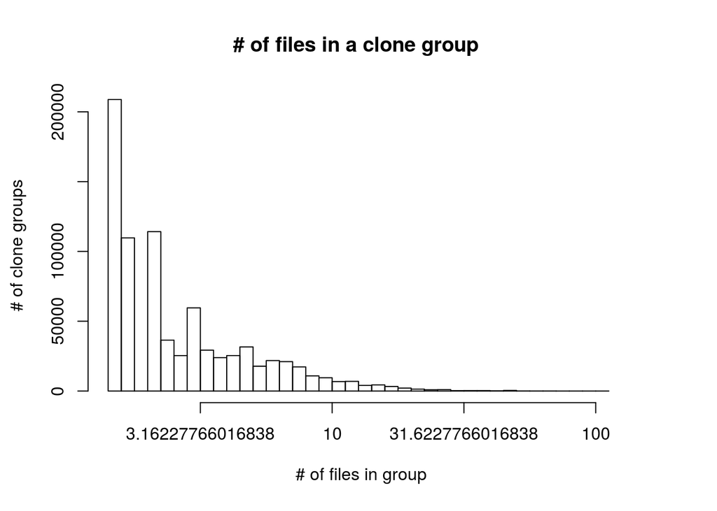

```r
# projects per clone group statistic
displayProjectsPerCloneGroup("tokenizer_clone_groups")
```

```
##    Min. 1st Qu.  Median    Mean 3rd Qu.    Max.
##    1.00    2.00    4.00   14.15   12.00 2855.00
```

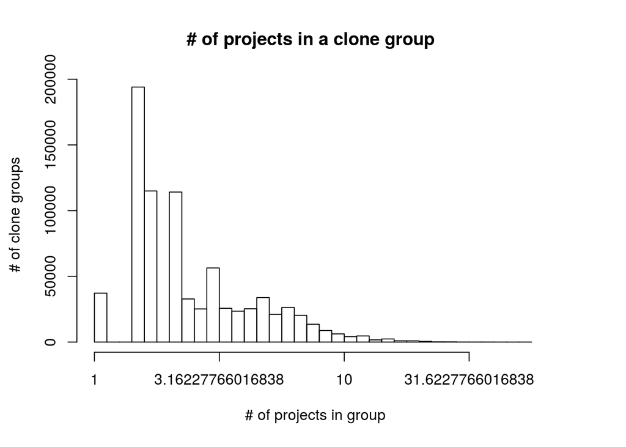

```r
# Links to mostly cloned files, ordered by absolute number of copies
mostClonedFiles("tokenizer_clone_groups", countBy = "files")
```

| url | files | projects |
| --- | --- | --- |
| https://github.com/narendly/decide/blob/master/node_modules/es6-symbol/test/is-native-implemented.js | 11346 | 114 |
| https://github.com/narendly/decide/blob/master/node_modules/es5-ext/test/math/atanh/index.js | 9486 | 114 |
| https://github.com/0921www/bootstrap-translation/blob/master/assets/js/google-code-prettify/prettify.js | 7360 | 2855 |
| https://github.com/0-wiz-0/jquery-ui/blob/master/external/jquery-1.9.1/jquery.js | 4566 | 2034 |
| https://github.com/0921www/bootstrap-translation/blob/master/assets/js/jquery.js | 4492 | 2749 |
| https://github.com/phinett/URI.js/blob/master/prettify/lang-css.js | 4196 | 982 |
| https://github.com/01walid/git-guide/blob/master/js/jquery-1.7.1.min.js | 4186 | 1897 |
| https://github.com/wajditcb/code-prettify/blob/master/loader/lang-proto.js | 4177 | 778 |
| https://github.com/phinett/URI.js/blob/master/prettify/lang-xq.js | 4168 | 768 |
| https://github.com/0bara/brackets/blob/master/src/extensibility/node/node_modules/request/node_modules/hawk/index.js | 4051 | 798 |
| https://github.com/phinett/URI.js/blob/master/prettify/lang-yaml.js | 3954 | 777 |
| https://github.com/quarkup/jsencrypt/blob/master/jquery.js | 3844 | 2110 |
| https://github.com/repmekevets/todomvc/blob/master/assets/base.js | 3814 | 99 |
| https://github.com/phinett/URI.js/blob/master/prettify/lang-n.js | 3620 | 618 |
| https://github.com/phinett/URI.js/blob/master/prettify/lang-hs.js | 3620 | 618 |
| https://github.com/phinett/URI.js/blob/master/prettify/lang-lisp.js | 3620 | 618 |
| https://github.com/phinett/URI.js/blob/master/prettify/lang-clj.js | 3619 | 617 |
| https://github.com/phinett/URI.js/blob/master/prettify/lang-vhdl.js | 3614 | 616 |
| https://github.com/phinett/URI.js/blob/master/prettify/lang-sql.js | 3612 | 614 |
| https://github.com/phinett/URI.js/blob/master/prettify/lang-scala.js | 3605 | 607 |

```r
# Links to mostly cloned files, ordered by # of projects which contain them
mostClonedFiles("tokenizer_clone_groups", countBy = "projects")
```

| url | files | projects |
| --- | --- | --- |
| https://github.com/0921www/bootstrap-translation/blob/master/assets/js/google-code-prettify/prettify.js | 7360 | 2855 |
| https://github.com/0921www/bootstrap-translation/blob/master/assets/js/jquery.js | 4492 | 2749 |
| https://github.com/quarkup/jsencrypt/blob/master/jquery.js | 3844 | 2110 |
| https://github.com/0-wiz-0/jquery-ui/blob/master/external/jquery-1.9.1/jquery.js | 4566 | 2034 |
| https://github.com/01walid/git-guide/blob/master/js/jquery-1.7.1.min.js | 4186 | 1897 |
| https://github.com/0-wiz-0/jquery-ui/blob/master/external/jquery-1.7.1/jquery.js | 2397 | 1718 |
| https://github.com/hippietrail/jQuery-Splitter/blob/master/jquery.min.js | 2160 | 1594 |
| https://github.com/zakishaheen/cohorts/blob/master/jquery-1.8.2.min.js | 2509 | 1513 |
| https://github.com/0-wiz-0/jquery-ui/blob/master/external/jquery-2.0.3/jquery.js | 2600 | 1455 |
| https://github.com/0-wiz-0/jquery-ui/blob/master/external/jquery-1.10.2/jquery.js | 2480 | 1414 |
| https://github.com/0bara/brackets/blob/master/test/node/node_modules/fs-extra/node_modules/mkdirp/examples/pow.js | 2928 | 1355 |
| https://github.com/qqwweeaassdd/jQuery.dotdotdot/blob/master/jquery-1.8.3.min.js | 1988 | 1339 |
| https://github.com/0-wiz-0/jquery-ui/blob/master/external/jquery-1.7.2/jquery.js | 1678 | 1239 |
| https://github.com/0bara/brackets/blob/master/test/node/node_modules/fs-extra/node_modules/mkdirp/test/clobber.js | 2519 | 1166 |
| https://github.com/0bara/brackets/blob/master/test/node/node_modules/fs-extra/node_modules/mkdirp/test/chmod.js | 2513 | 1161 |
| https://github.com/louarnos/atc-challenge/blob/master/atc.js | 2181 | 1116 |
| https://github.com/0bara/brackets/blob/master/test/node/node_modules/fs-extra/node_modules/mkdirp/test/mkdirp.js | 2234 | 1089 |
| https://github.com/0bara/brackets/blob/master/test/node/node_modules/fs-extra/node_modules/mkdirp/test/race.js | 2235 | 1089 |
| https://github.com/0bara/brackets/blob/master/test/node/node_modules/fs-extra/node_modules/mkdirp/test/rel.js | 2235 | 1089 |
| https://github.com/0bara/brackets/blob/master/test/node/node_modules/fs-extra/node_modules/mkdirp/test/perm_sync.js | 2181 | 1078 |

```r
originalContent("tokenizer_project_stats_original", "files")
```

```
##    Min. 1st Qu.  Median    Mean 3rd Qu.    Max.
##  0.0000  0.0000  0.0769  0.3089  0.6000  1.0000
```

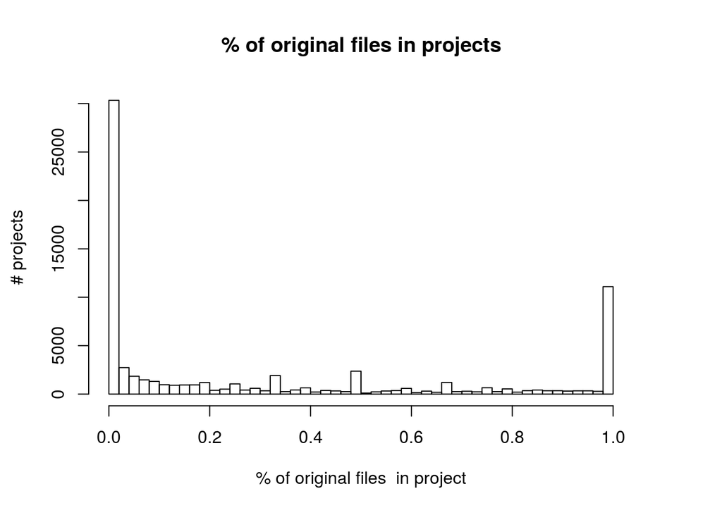

```r
originalContent("tokenizer_project_stats_original", "bytes")
```

```
##    Min. 1st Qu.  Median    Mean 3rd Qu.    Max.
##  0.0000  0.0000  0.0242  0.2907  0.6117  1.0000
```

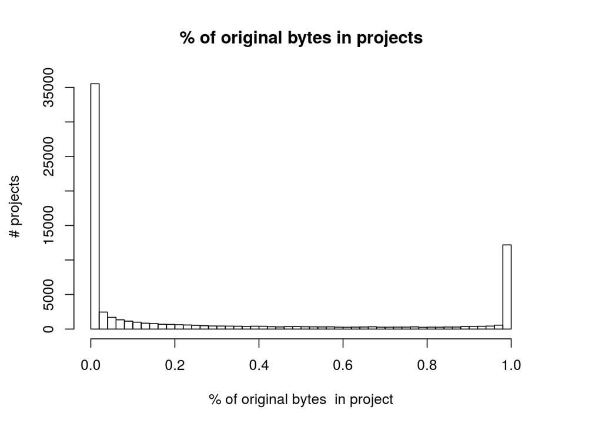

### Clones as reported by sourcerer

> These files are 70% or more compatible.

# Extra Stuff

## More about this notebook

> TODO explain how the notebook works

# OLD STUFF TO BE REINCORPORATED INTO THE DOCUMENT

#### Setting up MySQL

Download MySQL using the default Linux (I can’t speak for mac’s) packages. It will prompt for root password - I am happily using that one. In order to be (a) able to load the data from disk, and (b) make MySQL a bit faster than the default, go into the `/etc/mysql/mysql.conf.d/mysqld.conf` and append:

```
secure_file_priv=""
innodb_buffer_pool_size=10G # the more the better
innodb_log_file_size=512M
query_cache_size=0
```

> I have copied those from the internet and claim *no* real understanding of what they do - all I know the first one allows data loading, the second one sets memory.

Once you have updated the config file, run:

```
sudo service mysql restart
```

Then connect to it using your favourite client (mine is [DataGrip](https://www.jetbrains.com/datagrip/)) and create the databases (and usernames if you do not want to use root access). You do not have to worry about the tables as they will be automatically created when the script runs (make sure you uncomment the data loading below).

Mondego guys have a guide for using MySQL for data analysis available [here](https://github.com/Mondego/SourcererCC/blob/master/tokenizers/file-level/FileStats2MySQL.howto). It talks about python only a I had to adjust a few things on my computer to make it work, notably loading the data looks like:

```
LOAD DATA LOCAL INFILE filename INTO TABLE tablename;
```